# Data transformation

# 5.1 Data Transformation

*Load packages*

```r
#install.packages("nycflights13")
#install.packages("Lahman") # for the baseball example
library(tidyverse) #loads the tidyverse packages
library(nycflights13) #you will probably need to install this package as well
library(Lahman)
```

hmm, flights is a tibble, slightly different than a dataframe, tweaked to work better in tidyverse View(flights)

five key dplyr functions that solve vast majority of data manipulation challenges: filter() - pick observations by their values arrange() - reorder the rows select() - pick variables by names mutate() - create new variables with functions of existing variables summarise() - collapse many values down to single summary

all these verbs work similarly; 1st arg is data frame 2nd arg says what to do with data frame using the variable names the result is a new data frame

# 5.2 filter()

https://r4ds.had.co.nz/transform.html#exercises-8

two different ways to filter by flights that were not delayed at either end by more than 2 hours: filter(flights, !(arr_delay > 120 | dep_delay > 120)) filter(flights, arr_delay <= 120, dep_delay <= 120)

## 5.2.1

1. Use `filter` and the `'flights` dataset to answer the following questions. You can use `?flights` to learn more about each column in the dataset.
1. Had an arrival delay of two or more hours (note that dep_delay is in minutes and negative value represent early departures)

```r
arr_two <- filter(flights, arr_delay >= 120)
```

2. Flew to Houston (IAH or HOU)

```r
h_town <- filter(flights, dest == 'IAH' | dest == 'HOU')
```

3. Were operated by United (UA), American (AA), or Delta (DL)

```r
big_three <- filter(flights, carrier == 'UA' | carrier == 'AA' | carrier == 'DL')
# also can do like this:
big_three <- filter(flights, carrier %in% c("AA", "DL", "UA"))
```

4. Departed in summer (July, August, and September)

```r
summer_time <- filter(flights, month %in% c(7,8,9)) # could also use | here
```

5. Arrived more than two hours late, but didn’t leave late

```r
arr_two_dep_ontime <- filter(flights, arr_delay > 120 | dep_delay <= 0)
```

6. Were delayed by at least an hour, but made up over 30 minutes in flight

```r
speedy <- filter(flights, dep_delay >= 60 | arr_delay <= dep_delay - 30)
```

7. Departed between midnight and 6am (inclusive)

```r
red_eye <- filter(flights, dep_time <= 360 | dep_time == 2400)
```

##5.2.2 2. Another useful dplyr filtering helper is between(). What does it do? Can you use it to simplify the code needed to answer the previous challenges?

between() finds values between max and min values

```r
summer_time <- filter(flights, between(month, 7, 9))
```

## 5.2.3

3. How many flights have a missing dep_time? What other variables are missing? What might these rows represent?

8255 flights missing dep_time, seems like these were cancelled b/c other values are also missing

```r
idk <- filter(flights, is.na(dep_time))
```

## 5.2.4

4. Why is NA ^ 0 not missing? Why is NA | TRUE not missing? Why is FALSE & NA not missing?

Can you figure out the general rule? (NA * 0 is a tricky counterexample!) NA ^ 0 = 1 b/c all numbers ^ 0 =1 “NA | TRUE is TRUE because anything or TRUE is TRUE” “The value of NA & FALSE is FALSE because anything and FALSE is always FALSE” “b/c some possibilities are undefined, idk too mathy!

# 5.3 arrange()

https://r4ds.had.co.nz/transform.html#exercises-9

Here we will be sorting datasets using the `arrange` function. arrange changes the order of rows

## 5.3.1

1. How could you use `arrange()` to sort all missing values of departure time to the start? (Hint: use `desc(is.na())` to put NA’s first).

```r
arrange(flights, desc(is.na(dep_time)), dep_time) #1st sort by dep_time with NAs first - b/c asking true or false is dep_time NA? so False will come before True!, then sort by dep_time actual values - super cool!
```

| year | month | day | dep_time | sched_dep_time | dep_delay | arr_time | sched_arr_time | arr_delay | carrier | flight | tailnum | origin | dest | air_time | distance | hour | minute | time_hour |
| --- | --- | --- | --- | --- | --- | --- | --- | --- | --- | --- | --- | --- | --- | --- | --- | --- | --- | --- |
| 2013 | 1 | 1 | NA | 1630 | NA | NA | 1815 | NA | EV | 4308 | N18120 | EWR | RDU | NA | 416 | 16 | 30 | 2013-01-01 16:00:00 |
| 2013 | 1 | 1 | NA | 1935 | NA | NA | 2240 | NA | AA | 791 | N3EHAA | LGA | DFW | NA | 1389 | 19 | 35 | 2013-01-01 19:00:00 |
| 2013 | 1 | 1 | NA | 1500 | NA | NA | 1825 | NA | AA | 1925 | N3EVAA | LGA | MIA | NA | 1096 | 15 | 0 | 2013-01-01 15:00:00 |
| 2013 | 1 | 1 | NA | 600 | NA | NA | 901 | NA | B6 | 125 | N618JB | JFK | FLL | NA | 1069 | 6 | 0 | 2013-01-01 06:00:00 |
| 2013 | 1 | 2 | NA | 1540 | NA | NA | 1747 | NA | EV | 4352 | N10575 | EWR | CVG | NA | 569 | 15 | 40 | 2013-01-02 15:00:00 |
| 2013 | 1 | 2 | NA | 1620 | NA | NA | 1746 | NA | EV | 4406 | N13949 | EWR | PIT | NA | 319 | 16 | 20 | 2013-01-02 16:00:00 |
| 2013 | 1 | 2 | NA | 1355 | NA | NA | 1459 | NA | EV | 4434 | N10575 | EWR | MHT | NA | 209 | 13 | 55 | 2013-01-02 13:00:00 |
| 2013 | 1 | 2 | NA | 1420 | NA | NA | 1644 | NA | EV | 4935 | N759EV | EWR | ATL | NA | 746 | 14 | 20 | 2013-01-02 14:00:00 |
| 2013 | 1 | 2 | NA | 1321 | NA | NA | 1536 | NA | EV | 3849 | N13550 | EWR | IND | NA | 645 | 13 | 21 | 2013-01-02 13:00:00 |
| 2013 | 1 | 2 | NA | 1545 | NA | NA | 1910 | NA | AA | 133 | NA | JFK | LAX | NA | 2475 | 15 | 45 | 2013-01-02 15:00:00 |

[output cut: 990 more lines]

## 5.3.2

2. Sort flights to find the most delayed flights. Which flight left the earliest out of all flights?

most delayed flight was HA 51 from JFK to HNL - ooph! earliest departure was flight B6 97

```r
arrange(flights, desc(arr_delay))
```

| year | month | day | dep_time | sched_dep_time | dep_delay | arr_time | sched_arr_time | arr_delay | carrier | flight | tailnum | origin | dest | air_time | distance | hour | minute | time_hour |
| --- | --- | --- | --- | --- | --- | --- | --- | --- | --- | --- | --- | --- | --- | --- | --- | --- | --- | --- |
| 2013 | 1 | 9 | 641 | 900 | 1301 | 1242 | 1530 | 1272 | HA | 51 | N384HA | JFK | HNL | 640 | 4983 | 9 | 0 | 2013-01-09 09:00:00 |
| 2013 | 6 | 15 | 1432 | 1935 | 1137 | 1607 | 2120 | 1127 | MQ | 3535 | N504MQ | JFK | CMH | 74 | 483 | 19 | 35 | 2013-06-15 19:00:00 |
| 2013 | 1 | 10 | 1121 | 1635 | 1126 | 1239 | 1810 | 1109 | MQ | 3695 | N517MQ | EWR | ORD | 111 | 719 | 16 | 35 | 2013-01-10 16:00:00 |
| 2013 | 9 | 20 | 1139 | 1845 | 1014 | 1457 | 2210 | 1007 | AA | 177 | N338AA | JFK | SFO | 354 | 2586 | 18 | 45 | 2013-09-20 18:00:00 |
| 2013 | 7 | 22 | 845 | 1600 | 1005 | 1044 | 1815 | 989 | MQ | 3075 | N665MQ | JFK | CVG | 96 | 589 | 16 | 0 | 2013-07-22 16:00:00 |
| 2013 | 4 | 10 | 1100 | 1900 | 960 | 1342 | 2211 | 931 | DL | 2391 | N959DL | JFK | TPA | 139 | 1005 | 19 | 0 | 2013-04-10 19:00:00 |
| 2013 | 3 | 17 | 2321 | 810 | 911 | 135 | 1020 | 915 | DL | 2119 | N927DA | LGA | MSP | 167 | 1020 | 8 | 10 | 2013-03-17 08:00:00 |
| 2013 | 7 | 22 | 2257 | 759 | 898 | 121 | 1026 | 895 | DL | 2047 | N6716C | LGA | ATL | 109 | 762 | 7 | 59 | 2013-07-22 07:00:00 |
| 2013 | 12 | 5 | 756 | 1700 | 896 | 1058 | 2020 | 878 | AA | 172 | N5DMAA | EWR | MIA | 149 | 1085 | 17 | 0 | 2013-12-05 17:00:00 |
| 2013 | 5 | 3 | 1133 | 2055 | 878 | 1250 | 2215 | 875 | MQ | 3744 | N523MQ | EWR | ORD | 112 | 719 | 20 | 55 | 2013-05-03 20:00:00 |

[output cut: 990 more lines]

```r
# earliest flight will have lowest dep_delay - so arrange by this
arrange(flights, dep_delay)
```

| year | month | day | dep_time | sched_dep_time | dep_delay | arr_time | sched_arr_time | arr_delay | carrier | flight | tailnum | origin | dest | air_time | distance | hour | minute | time_hour |
| --- | --- | --- | --- | --- | --- | --- | --- | --- | --- | --- | --- | --- | --- | --- | --- | --- | --- | --- |
| 2013 | 12 | 7 | 2040 | 2123 | -43 | 40 | 2352 | 48 | B6 | 97 | N592JB | JFK | DEN | 265 | 1626 | 21 | 23 | 2013-12-07 21:00:00 |
| 2013 | 2 | 3 | 2022 | 2055 | -33 | 2240 | 2338 | -58 | DL | 1715 | N612DL | LGA | MSY | 162 | 1183 | 20 | 55 | 2013-02-03 20:00:00 |
| 2013 | 11 | 10 | 1408 | 1440 | -32 | 1549 | 1559 | -10 | EV | 5713 | N825AS | LGA | IAD | 52 | 229 | 14 | 40 | 2013-11-10 14:00:00 |
| 2013 | 1 | 11 | 1900 | 1930 | -30 | 2233 | 2243 | -10 | DL | 1435 | N934DL | LGA | TPA | 139 | 1010 | 19 | 30 | 2013-01-11 19:00:00 |
| 2013 | 1 | 29 | 1703 | 1730 | -27 | 1947 | 1957 | -10 | F9 | 837 | N208FR | LGA | DEN | 250 | 1620 | 17 | 30 | 2013-01-29 17:00:00 |
| 2013 | 8 | 9 | 729 | 755 | -26 | 1002 | 955 | 7 | MQ | 3478 | N711MQ | LGA | DTW | 88 | 502 | 7 | 55 | 2013-08-09 07:00:00 |
| 2013 | 10 | 23 | 1907 | 1932 | -25 | 2143 | 2143 | 0 | EV | 4361 | N13994 | EWR | TYS | 111 | 631 | 19 | 32 | 2013-10-23 19:00:00 |
| 2013 | 3 | 30 | 2030 | 2055 | -25 | 2213 | 2250 | -37 | MQ | 4573 | N725MQ | LGA | DTW | 87 | 502 | 20 | 55 | 2013-03-30 20:00:00 |
| 2013 | 3 | 2 | 1431 | 1455 | -24 | 1601 | 1631 | -30 | 9E | 3318 | N929XJ | JFK | BUF | 55 | 301 | 14 | 55 | 2013-03-02 14:00:00 |
| 2013 | 5 | 5 | 934 | 958 | -24 | 1225 | 1309 | -44 | B6 | 375 | N531JB | LGA | FLL | 150 | 1076 | 9 | 58 | 2013-05-05 09:00:00 |

[output cut: 990 more lines]

## 5.3.3

3. Sort flights to find the fastest (highest speed) flights. Which flight is shortest?

there was one that was only 1hr 6 minutes - missing some other data tho

```r
arrange(flights, desc(distance / air_time))
```

| year | month | day | dep_time | sched_dep_time | dep_delay | arr_time | sched_arr_time | arr_delay | carrier | flight | tailnum | origin | dest | air_time | distance | hour | minute | time_hour |
| --- | --- | --- | --- | --- | --- | --- | --- | --- | --- | --- | --- | --- | --- | --- | --- | --- | --- | --- |
| 2013 | 5 | 25 | 1709 | 1700 | 9 | 1923 | 1937 | -14 | DL | 1499 | N666DN | LGA | ATL | 65 | 762 | 17 | 0 | 2013-05-25 17:00:00 |
| 2013 | 7 | 2 | 1558 | 1513 | 45 | 1745 | 1719 | 26 | EV | 4667 | N17196 | EWR | MSP | 93 | 1008 | 15 | 13 | 2013-07-02 15:00:00 |
| 2013 | 5 | 13 | 2040 | 2025 | 15 | 2225 | 2226 | -1 | EV | 4292 | N14568 | EWR | GSP | 55 | 594 | 20 | 25 | 2013-05-13 20:00:00 |
| 2013 | 3 | 23 | 1914 | 1910 | 4 | 2045 | 2043 | 2 | EV | 3805 | N12567 | EWR | BNA | 70 | 748 | 19 | 10 | 2013-03-23 19:00:00 |
| 2013 | 1 | 12 | 1559 | 1600 | -1 | 1849 | 1917 | -28 | DL | 1902 | N956DL | LGA | PBI | 105 | 1035 | 16 | 0 | 2013-01-12 16:00:00 |
| 2013 | 11 | 17 | 650 | 655 | -5 | 1059 | 1150 | -51 | DL | 315 | N3768 | JFK | SJU | 170 | 1598 | 6 | 55 | 2013-11-17 06:00:00 |
| 2013 | 2 | 21 | 2355 | 2358 | -3 | 412 | 438 | -26 | B6 | 707 | N779JB | JFK | SJU | 172 | 1598 | 23 | 58 | 2013-02-21 23:00:00 |
| 2013 | 11 | 17 | 759 | 800 | -1 | 1212 | 1255 | -43 | AA | 936 | N5FFAA | JFK | STT | 175 | 1623 | 8 | 0 | 2013-11-17 08:00:00 |
| 2013 | 11 | 16 | 2003 | 1925 | 38 | 17 | 36 | -19 | DL | 347 | N3773D | JFK | SJU | 173 | 1598 | 19 | 25 | 2013-11-16 19:00:00 |
| 2013 | 11 | 16 | 2349 | 2359 | -10 | 402 | 440 | -38 | B6 | 1503 | N571JB | JFK | SJU | 173 | 1598 | 23 | 59 | 2013-11-16 23:00:00 |

[output cut: 990 more lines]

## 5.3.4

4. Which flights travelled the farthest? How many miles was that trip? Which travelled the shortest? Do you think the passengers of this shortest flight were planning on this destination?

```r
arrange(flights, desc(distance))
```

| year | month | day | dep_time | sched_dep_time | dep_delay | arr_time | sched_arr_time | arr_delay | carrier | flight | tailnum | origin | dest | air_time | distance | hour | minute | time_hour |
| --- | --- | --- | --- | --- | --- | --- | --- | --- | --- | --- | --- | --- | --- | --- | --- | --- | --- | --- |
| 2013 | 1 | 1 | 857 | 900 | -3 | 1516 | 1530 | -14 | HA | 51 | N380HA | JFK | HNL | 659 | 4983 | 9 | 0 | 2013-01-01 09:00:00 |
| 2013 | 1 | 2 | 909 | 900 | 9 | 1525 | 1530 | -5 | HA | 51 | N380HA | JFK | HNL | 638 | 4983 | 9 | 0 | 2013-01-02 09:00:00 |
| 2013 | 1 | 3 | 914 | 900 | 14 | 1504 | 1530 | -26 | HA | 51 | N380HA | JFK | HNL | 616 | 4983 | 9 | 0 | 2013-01-03 09:00:00 |
| 2013 | 1 | 4 | 900 | 900 | 0 | 1516 | 1530 | -14 | HA | 51 | N384HA | JFK | HNL | 639 | 4983 | 9 | 0 | 2013-01-04 09:00:00 |
| 2013 | 1 | 5 | 858 | 900 | -2 | 1519 | 1530 | -11 | HA | 51 | N381HA | JFK | HNL | 635 | 4983 | 9 | 0 | 2013-01-05 09:00:00 |
| 2013 | 1 | 6 | 1019 | 900 | 79 | 1558 | 1530 | 28 | HA | 51 | N385HA | JFK | HNL | 611 | 4983 | 9 | 0 | 2013-01-06 09:00:00 |
| 2013 | 1 | 7 | 1042 | 900 | 102 | 1620 | 1530 | 50 | HA | 51 | N385HA | JFK | HNL | 612 | 4983 | 9 | 0 | 2013-01-07 09:00:00 |
| 2013 | 1 | 8 | 901 | 900 | 1 | 1504 | 1530 | -26 | HA | 51 | N389HA | JFK | HNL | 645 | 4983 | 9 | 0 | 2013-01-08 09:00:00 |
| 2013 | 1 | 9 | 641 | 900 | 1301 | 1242 | 1530 | 1272 | HA | 51 | N384HA | JFK | HNL | 640 | 4983 | 9 | 0 | 2013-01-09 09:00:00 |
| 2013 | 1 | 10 | 859 | 900 | -1 | 1449 | 1530 | -41 | HA | 51 | N388HA | JFK | HNL | 633 | 4983 | 9 | 0 | 2013-01-10 09:00:00 |

[output cut: 990 more lines]

```r
arrange(flights, distance)
```

| year | month | day | dep_time | sched_dep_time | dep_delay | arr_time | sched_arr_time | arr_delay | carrier | flight | tailnum | origin | dest | air_time | distance | hour | minute | time_hour |
| --- | --- | --- | --- | --- | --- | --- | --- | --- | --- | --- | --- | --- | --- | --- | --- | --- | --- | --- |
| 2013 | 7 | 27 | NA | 106 | NA | NA | 245 | NA | US | 1632 | NA | EWR | LGA | NA | 17 | 1 | 6 | 2013-07-27 01:00:00 |
| 2013 | 1 | 3 | 2127 | 2129 | -2 | 2222 | 2224 | -2 | EV | 3833 | N13989 | EWR | PHL | 30 | 80 | 21 | 29 | 2013-01-03 21:00:00 |
| 2013 | 1 | 4 | 1240 | 1200 | 40 | 1333 | 1306 | 27 | EV | 4193 | N14972 | EWR | PHL | 30 | 80 | 12 | 0 | 2013-01-04 12:00:00 |
| 2013 | 1 | 4 | 1829 | 1615 | 134 | 1937 | 1721 | 136 | EV | 4502 | N15983 | EWR | PHL | 28 | 80 | 16 | 15 | 2013-01-04 16:00:00 |
| 2013 | 1 | 4 | 2128 | 2129 | -1 | 2218 | 2224 | -6 | EV | 4645 | N27962 | EWR | PHL | 32 | 80 | 21 | 29 | 2013-01-04 21:00:00 |
| 2013 | 1 | 5 | 1155 | 1200 | -5 | 1241 | 1306 | -25 | EV | 4193 | N14902 | EWR | PHL | 29 | 80 | 12 | 0 | 2013-01-05 12:00:00 |
| 2013 | 1 | 6 | 2125 | 2129 | -4 | 2224 | 2224 | 0 | EV | 4619 | N22909 | EWR | PHL | 22 | 80 | 21 | 29 | 2013-01-06 21:00:00 |
| 2013 | 1 | 7 | 2124 | 2129 | -5 | 2212 | 2224 | -12 | EV | 4619 | N33182 | EWR | PHL | 25 | 80 | 21 | 29 | 2013-01-07 21:00:00 |
| 2013 | 1 | 8 | 2127 | 2130 | -3 | 2304 | 2225 | 39 | EV | 4619 | N11194 | EWR | PHL | 30 | 80 | 21 | 30 | 2013-01-08 21:00:00 |
| 2013 | 1 | 9 | 2126 | 2129 | -3 | 2217 | 2224 | -7 | EV | 4619 | N17560 | EWR | PHL | 27 | 80 | 21 | 29 | 2013-01-09 21:00:00 |

[output cut: 990 more lines]

# 5.4 select()

Here we will be using the `select` command to extract columns from a dataset. https://r4ds.had.co.nz/transform.html#exercises-10

use rename() to rename variables, better than select() b/c it holds onto all variables that aren’t explicity called

can do select() with everything to move selected variables up to the start of a df select(flights, time_hour, air_time, everything())

## 5.4.1

1. Select `dep_time`, `dep_delay`, `arr_time`, and `arr_delay` from `flights`.

```r
select(flights, dep_time, dep_delay, sched_arr_time, arr_delay)
```

| dep_time | dep_delay | sched_arr_time | arr_delay |
| --- | --- | --- | --- |
| 517 | 2 | 819 | 11 |
| 533 | 4 | 830 | 20 |
| 542 | 2 | 850 | 33 |
| 544 | -1 | 1022 | -18 |
| 554 | -6 | 837 | -25 |
| 554 | -4 | 728 | 12 |
| 555 | -5 | 854 | 19 |
| 557 | -3 | 723 | -14 |
| 557 | -3 | 846 | -8 |
| 558 | -2 | 745 | 8 |

[output cut: 990 more lines]

## 5.4.2

2. What happens if you include the name of a variable multiple times in a select() call?

```r
subset <- select(flights, dep_time, dep_time, dep_delay, sched_arr_time, arr_delay)
# doesnt seem to make a difference?
```

## 5.4.3

3. What does the `any_of()` function do? Why might it be helpful in conjunction with this vector below?

any_of() is a selection helper - doesn’t check for missing variables. especially useful for negative selections when like to make sure a variable is removed

```r
vars <- c("year", "month", "day", "dep_delay", "arr_dely")

subset <- select(flights, any_of(vars)) # says keep only the variables vars in flights, can also use negative selection with -
```

## 5.4.4

4. Does the result of running the following code surprise you? How do the select helpers deal with case by default? How can you change that default?

I am surprised! they don’t care about case! can use ignore.case=FALSE to change this if need

```r
select(flights, contains("TIME"))
```

| dep_time | sched_dep_time | arr_time | sched_arr_time | air_time | time_hour |
| --- | --- | --- | --- | --- | --- |
| 517 | 515 | 830 | 819 | 227 | 2013-01-01 05:00:00 |
| 533 | 529 | 850 | 830 | 227 | 2013-01-01 05:00:00 |
| 542 | 540 | 923 | 850 | 160 | 2013-01-01 05:00:00 |
| 544 | 545 | 1004 | 1022 | 183 | 2013-01-01 05:00:00 |
| 554 | 600 | 812 | 837 | 116 | 2013-01-01 06:00:00 |
| 554 | 558 | 740 | 728 | 150 | 2013-01-01 05:00:00 |
| 555 | 600 | 913 | 854 | 158 | 2013-01-01 06:00:00 |
| 557 | 600 | 709 | 723 | 53 | 2013-01-01 06:00:00 |
| 557 | 600 | 838 | 846 | 140 | 2013-01-01 06:00:00 |
| 558 | 600 | 753 | 745 | 138 | 2013-01-01 06:00:00 |

[output cut: 990 more lines]

# 5.5 mutate()

Modifying and adding columns with `mutate`. https://r4ds.had.co.nz/transform.html#exercises-11

if you just want to keep the new variables can use transmute()

## 5.5.1

1. Currently `dep_time` and `sched_dep_time` are convenient to look at, but hard to compute with because they’re not really continuous numbers. Convert them to a more convenient representation of number of minutes since midnight. (*Hint: `dep_time%/%100` will extract the number of hours and `dep_time%%60` will return the number of minutes*)

```r
# modulus - stuff from Jake
flights_new <- mutate(flights, dep_time=dep_time%/%100*60 + dep_time%%100, arr_time=arr_time%/%100*60 + arr_time%%100)
```

## 5.5.2

2. Compare `air_time` with `arr_time - dep_time`. What do you expect to see? What do you see? What do you need to do to fix it?

I would expect that air_time would equal arr_time - dep_time, but the value for air_time did not equal this, so redid air_time as arr_time - dep_time

Looked at answers online, seems that taxi time is not included, so air_time is <= arr_time - dep_time assuming the flights are on the same day within the same timeframe

```r
#flights <- mutate(flights,air_time = arr_time - dep_time)
```

## 5.5.3

3. Compare `dep_time`, `sched_dep_time`, and `dep_delay`. How would you expect those three numbers to be related?

I would expect that `dep_delay=dep_time - sched_dep_time

Cool workflow by the person that made the github answers sheet

```r
# make new variable called dep_delay_diff based on assumption that dep_delay=dep_time - sched_dep_time
# assumes we haven't manipulated variables with modulus yet
flights_deptime <-
  mutate(flights,
    dep_time_min = (dep_time %/% 100 * 60 + dep_time %% 100) %% 1440,
    sched_dep_time_min = (sched_dep_time %/% 100 * 60 +
      sched_dep_time %% 100) %% 1440,
    dep_delay_diff = dep_delay - dep_time_min + sched_dep_time_min
  )

# then can test assumption - does this difference = 0?
filter(flights_deptime, dep_delay_diff != 0)
```

| year | month | day | dep_time | sched_dep_time | dep_delay | arr_time | sched_arr_time | arr_delay | carrier | flight | tailnum | origin | dest | air_time | distance | hour | minute | time_hour | dep_time_min | sched_dep_time_min | dep_delay_diff |
| --- | --- | --- | --- | --- | --- | --- | --- | --- | --- | --- | --- | --- | --- | --- | --- | --- | --- | --- | --- | --- | --- |
| 2013 | 1 | 1 | 848 | 1835 | 853 | 1001 | 1950 | 851 | MQ | 3944 | N942MQ | JFK | BWI | 41 | 184 | 18 | 35 | 2013-01-01 18:00:00 | 528 | 1115 | 1440 |
| 2013 | 1 | 2 | 42 | 2359 | 43 | 518 | 442 | 36 | B6 | 707 | N580JB | JFK | SJU | 189 | 1598 | 23 | 59 | 2013-01-02 23:00:00 | 42 | 1439 | 1440 |
| 2013 | 1 | 2 | 126 | 2250 | 156 | 233 | 2359 | 154 | B6 | 22 | N636JB | JFK | SYR | 49 | 209 | 22 | 50 | 2013-01-02 22:00:00 | 86 | 1370 | 1440 |
| 2013 | 1 | 3 | 32 | 2359 | 33 | 504 | 442 | 22 | B6 | 707 | N763JB | JFK | SJU | 193 | 1598 | 23 | 59 | 2013-01-03 23:00:00 | 32 | 1439 | 1440 |
| 2013 | 1 | 3 | 50 | 2145 | 185 | 203 | 2311 | 172 | B6 | 104 | N329JB | JFK | BUF | 58 | 301 | 21 | 45 | 2013-01-03 21:00:00 | 50 | 1305 | 1440 |
| 2013 | 1 | 3 | 235 | 2359 | 156 | 700 | 437 | 143 | B6 | 727 | N618JB | JFK | BQN | 186 | 1576 | 23 | 59 | 2013-01-03 23:00:00 | 155 | 1439 | 1440 |
| 2013 | 1 | 4 | 25 | 2359 | 26 | 505 | 442 | 23 | B6 | 707 | N554JB | JFK | SJU | 194 | 1598 | 23 | 59 | 2013-01-04 23:00:00 | 25 | 1439 | 1440 |
| 2013 | 1 | 4 | 106 | 2245 | 141 | 201 | 2356 | 125 | B6 | 608 | N192JB | JFK | PWM | 44 | 273 | 22 | 45 | 2013-01-04 22:00:00 | 66 | 1365 | 1440 |
| 2013 | 1 | 5 | 14 | 2359 | 15 | 503 | 445 | 18 | B6 | 739 | N592JB | JFK | PSE | 201 | 1617 | 23 | 59 | 2013-01-05 23:00:00 | 14 | 1439 | 1440 |
| 2013 | 1 | 5 | 37 | 2230 | 127 | 341 | 131 | 130 | B6 | 11 | N527JB | JFK | FLL | 163 | 1069 | 22 | 30 | 2013-01-05 22:00:00 | 37 | 1350 | 1440 |

[output cut: 990 more lines]

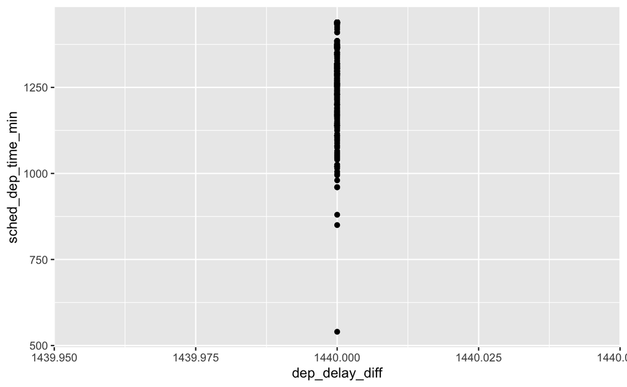

```r
# its clear that not all of these dep_delay_diffs are 0! what's going on here?
ggplot(
  filter(flights_deptime, dep_delay_diff > 0),
  aes(y = sched_dep_time_min, x = dep_delay_diff)
) +
  geom_point()
```

```r
# clear that all of the points with dep_delay_diff != 0 are at 1440 - this is midnight! just due to a strange way that this was recorded in the dataframe
```

## 5.5.4

4. Find the 10 most delayed flights using a ranking function. How do you want to handle ties? Carefully read the documentation for `min_rank()`. (*Hint, its probably easiest to use filter here*)

min_rank() and dense_rank() both differ in how they assign the next value after ties can use filter and rank argument 51, 3535, 3695, 177 are the most delayed flights

```r
most_delay <- flights %>% filter(rank(desc(arr_delay)) <= 10)
# cool, this works!
# this just ranks the top 10 arr_delays! cool
```

## 5.5.5

5. What does `1:3 + 1:10` return? Why? This produces a vector of length 10 and a warning because the shorter object is recycled.

```r
1:3 + 1:10
```

```
Warning: longer object length is not a multiple of shorter object length
```

```
 [1]  2  4  6  5  7  9  8 10 12 11
```

6. What trigonometric functions does R provide? from ?Trig:

cos(x) sin(x) tan(x)

acos(x) asin(x) atan(x) atan2(y, x)

cospi(x) sinpi(x) tanpi(x)

# 5.6 summarise()

Summarising with `summarise` (note that `summarize` also works) and an intro to using pipes. https://r4ds.had.co.nz/transform.html#exercises-12

*summarise() collapses a df into a single row*

```r
summarise(flights, delay = mean(dep_delay, na.rm = TRUE))
summarise(flights, distance = mean(distance, na.rm = TRUE))
```

*summarise should be paired with group_by most of the time* cool! so this looks at the delay by day of the year together group_by and summarise produce grouped summaries - super common tool with dplyr use with group_by b/c most often looking for comparisons across groups, not just the whole df all together

*the pipe!* *cool - so along this process they’ve kept the counts ie the number of flights for each destination - Jake says (and we know from stats) that this will be important to consider when looking at regressions / statistical analyses*

relationship between distance and avg delay for each location

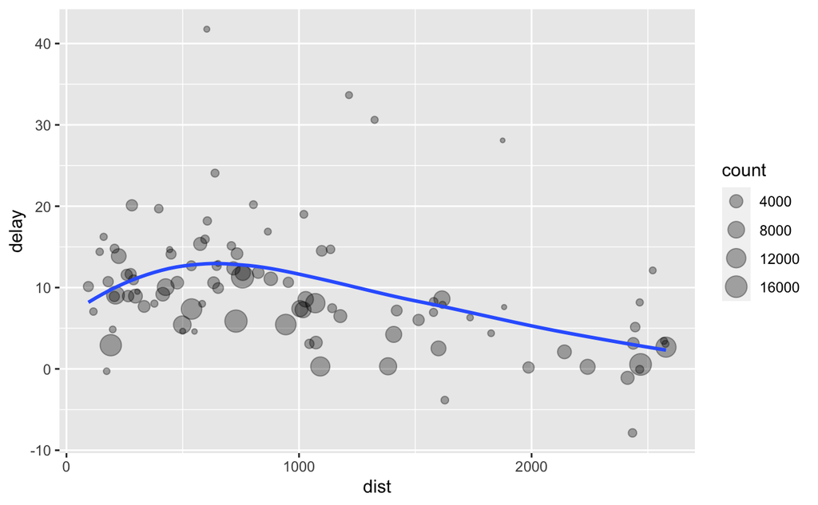

*but that code is a pain to write - had to make intermediate dfs*

##Pipe! *so lets use the pipe!*

*pipe says hold my beer* read as a series of imperative statements: group, then summarise, then filter pronounce %>% as “then”! piping improves the readiblity of code considerably! so will return to this again *using the pipe is key for the tidyverse! except for ggplot2, but stay tuned for ggvis!*

*let’s try another practice pipe* let’s look at how distance changes by air_time and airline?

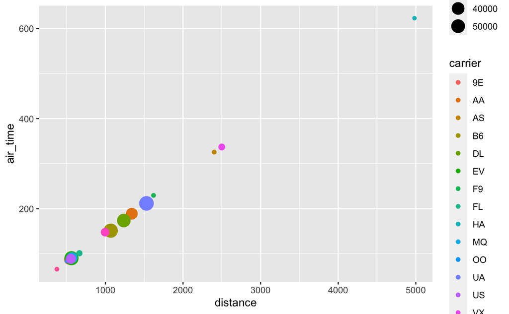

*cool! none of this is surprising, but we see that as distance goes up so does air_time in a perfectly linear way, same pattern for all airlines*

make a dataset only with flights that weren’t cancelled, easier going forward

*important to include counts when doing aggregations - so we can check that not drawing conclusions from very small data sizes*

```r
delays <- not_cancelled %>%
  group_by(tailnum) %>%
  summarise(
    delay = mean(arr_delay)
  )

ggplot(data = delays, mapping = aes(x = delay)) +
  geom_freqpoly(binwidth = 10)
```

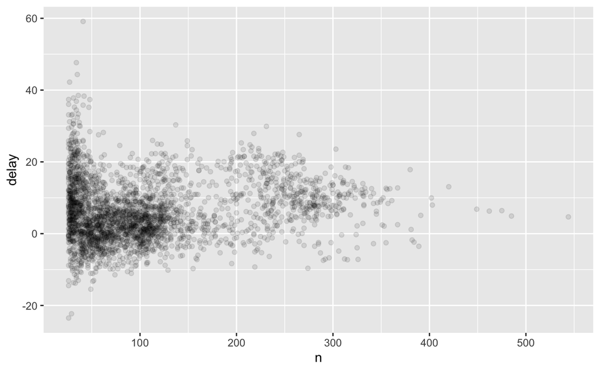

*much greater variation in delay when there are fewer flights (n is lower)*

## Baseball!

```r
# Convert to a tibble so it prints nicely
batting <- as_tibble(Lahman::Batting)

batters <- batting %>%
  group_by(playerID) %>%
  summarise(
    ba = sum(H, na.rm = TRUE) / sum(AB, na.rm = TRUE),
    ab = sum(AB, na.rm = TRUE)
  )

batters %>%
  filter(ab > 100) %>%
  ggplot(mapping = aes(x = ab, y = ba)) +
    geom_point() +
    geom_smooth(se = FALSE)
# also note that this is career-wide
```

[output not shown]

*see that variation in aggregate decreases as we get more data points and that there is a positive correlation between opportunities and skill - makes sense!*

```r
batters %>%
  arrange(desc(ba))
```

*run through some Mets specific things here* how does Mets specific plot compare to the league-wide one above? *obvi easier to wittle down above ex. - but practicing building up ba from mets specific df*

```r
mets_2021 <- batting %>%
  filter(yearID == 2021 & teamID == 'NYN')

mets_regulars <- mets_2021 %>%
  filter(AB >= 100)

mets_ba <- mets_2021 %>%
  group_by(playerID) %>%
  summarise(
    ba = sum(H, na.rm = TRUE) / sum(AB, na.rm = TRUE),
    ab = sum(AB, na.rm = TRUE)
  )

mets_ba %>%
  filter(ab > 100) %>%
  ggplot(mapping = aes(x = ab, y = ba)) +
           geom_point() +
           geom_smooth()
# lol! the Mets specific trend doesn follow that of the league,
# makes sense as they gave way too many at bats to bad players in 2021!
# but also this is single season, above was for a player's whole career
```

[output not shown]

[output cut: 990 more lines]

*useful summary functions* *sometimes useful to combine aggregation with logical subsetting.*

```r
not_cancelled %>%
  group_by(year, month, day) %>%
  summarise(
    avg_delay1 = mean(arr_delay),
    avg_delay2 = mean(arr_delay[arr_delay > 0]) # the average positive delay
  )
```

*measures of spread: sd(x), IQR(x), mad(x) - the last two could be more useful if have outliers*

```r
not_cancelled %>%
  group_by(dest) %>%
  summarise(distance_sd = sd(distance)) %>%
  arrange(desc(distance_sd))
```

*measures of rank: min(x), quantile(x, 0.25), max(x). quantiles are a generalisation of the median. ex above will find a value that is greater than 25% of the values and less than the remaining 75% (whereas median is at the 50% mark)*

```r
# When do the first and last flights leave each day?
not_cancelled %>%
  group_by(year, month, day) %>%
  summarise(
    first = min(dep_time),
    last = max(dep_time)
  )
```

```
#> # A tibble: 365 x 5
#> # Groups:   year, month [12]
#>    year month   day first  last
#>   <int> <int> <int> <int> <int>
#> 1  2013     1     1   517  2356
#> 2  2013     1     2    42  2354
#> 3  2013     1     3    32  2349
#> 4  2013     1     4    25  2358
#> 5  2013     1     5    14  2357
#> 6  2013     1     6    16  2355
#> # … with 359 more rows
```

*can also use first(x), nth(x, 2), last(x)* *can use a weight variable, ex. wt = distance to “count” ie sum the total number of miles a plane flew*

*grouping by multiple variables* *can progressively roll up data sets, this is okay for sums and counts but need to think about weighting means and variances*

```r
daily <- group_by(flights, year, month, day)
per_day <- summarise(daily, flights = n())
```

*ungrouping*

```r
daily %>%
  ungroup() %>%             # no longer grouped by date
  summarise(flights = n())  # all flights
```

## 5.6.1

1. Brainstorm at least 5 different ways to assess the typical delay characteristics of a group of flights. Consider the following scenarios: (I would advise just doing one or two of these)
- A flight is 15 minutes early 50% of the time, and 15 minutes late 50% of the time.
- A flight is always 10 minutes late.
- A flight is 30 minutes early 50% of the time, and 30 minutes late 50% of the time.
- 99% of the time a flight is on time. 1% of the time it’s 2 hours late.

*Ahh okay! So its important to think about variance and median and mean delays*

Which is more important: arrival delay or departure delay? arrival delay is more important

## 5.6.2

2. Come up with another approach that will give you the same output as `not_cancelled %>% count(dest)` and `not_cancelled %>% count(tailnum, wt = distance)` (without using `count()`).

| tailnum | n |
| --- | --- |
| D942DN | 3418 |
| N0EGMQ | 239143 |
| N10156 | 109664 |
| N102UW | 25722 |
| N103US | 24619 |
| N104UW | 24616 |
| N10575 | 139903 |
| N105UW | 23618 |
| N107US | 21677 |
| N108UW | 32070 |

[output cut: 990 more lines]

## 5.6.3

3. Our definition of cancelled flights (`is.na(dep_delay) | is.na(arr_delay)` ) is slightly suboptimal. Why? Which is the most important column? *seems like air_time could do this too, as if the flight arrives exactly on schedule, someone could input NA for delay?* *answer blog says just use arrive delay* aight

## 5.6.4

*my attempt*

```r
(per_month_cancelled   <- summarise(monthly_cancelled, flights = n()))
```

| year | month | flights |
| --- | --- | --- |
| 2013 | 1 | 521 |
| 2013 | 2 | 1261 |
| 2013 | 3 | 861 |
| 2013 | 4 | 668 |
| 2013 | 5 | 563 |
| 2013 | 6 | 1009 |
| 2013 | 7 | 940 |
| 2013 | 8 | 486 |
| 2013 | 9 | 452 |
| 2013 | 10 | 236 |

[output cut: 2 more lines]

*code from answers sheet*

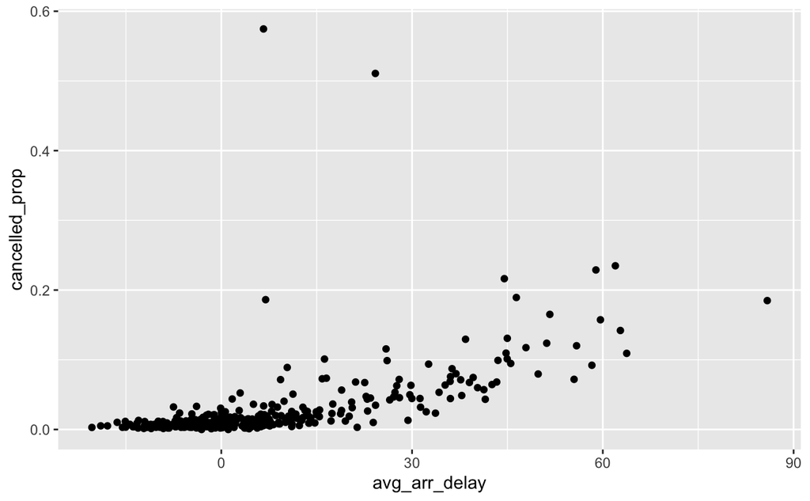

## 5.6.5

5. Which carrier has the worst delays? Challenge: can you disentangle the effects of bad airports vs. bad carriers? Why/why not? (Hint: think about `flights %>% group_by(carrier, dest) %>% summarise(n())`) F9 has med_arr_delay >5, only carrier

*my attempt*

```r
carrier_desc <- carrier %>% # another way, can arrange by descending order of dep_delay. this way is prob. better b/c keep all
    # carriers
  group_by(carrier) %>%
summarise(delay=median(dep_delay, na.rm=TRUE)) %>% #
  arrange(desc(delay))
```

[output not shown]

*code from answer blog* - says the same thing! F9 sucks *although disentangling airports and carriers shows OO with the highest avg delay difference*

```r
# trying to disentangle airport vs carrier effects is a lot harder
flights %>%
  filter(!is.na(arr_delay)) %>%
  # Total delay by carrier within each origin, dest
  group_by(origin, dest, carrier) %>%
  summarise(
    arr_delay = sum(arr_delay),
    flights = n()
  ) %>%
  # Total delay within each origin dest
  group_by(origin, dest) %>%
  mutate(
    arr_delay_total = sum(arr_delay),
    flights_total = sum(flights)
  ) %>%
  # average delay of each carrier - average delay of other carriers
  ungroup() %>%
  mutate(
    arr_delay_others = (arr_delay_total - arr_delay) /
      (flights_total - flights),
    arr_delay_mean = arr_delay / flights,
    arr_delay_diff = arr_delay_mean - arr_delay_others
  ) %>%
  # remove NaN values (when there is only one carrier)
  filter(is.finite(arr_delay_diff)) %>%
  # average over all airports it flies to
  group_by(carrier) %>%
  summarise(arr_delay_diff = mean(arr_delay_diff)) %>%
  arrange(desc(arr_delay_diff))
```

| carrier | arr_delay_diff |
| --- | --- |
| OO | 27.3357200 |
| F9 | 17.2846161 |
| EV | 11.0268330 |
| B6 | 6.4070110 |
| FL | 2.5724238 |
| VX | -0.2019972 |
| AA | -0.9696024 |
| WN | -1.2702534 |
| UA | -1.8628537 |
| MQ | -2.4759701 |

[output cut: 5 more lines]

## 5.6.6

6. What does the `sort` argument to `count()` do. When might you use it? *sort if tru (default is FALSE) will show the largest groups at the top* good way to show the carriers with the most flights first *could use anytime we run count() followed by arrange()

| dest | n |
| --- | --- |
| ORD | 17283 |
| ATL | 17215 |
| LAX | 16174 |
| BOS | 15508 |
| MCO | 14082 |
| CLT | 14064 |
| SFO | 13331 |
| FLL | 12055 |
| MIA | 11728 |
| DCA | 9705 |

[output cut: 95 more lines]

# 5.7

https://r4ds.had.co.nz/transform.html#exercises-13

Simultaneous grouping and summarizing!

## 5.7.1

1. Refer back to the lists of useful mutate and filtering functions. Describe how each operation changes when you combine it with grouping.

## 5.7.2

2. Which plane (tailnum) has the worst on-time record?

## 5.7.3

3. What time of day should you fly if you want to avoid delays as much as possible?

## 5.7.4

4. For each destination, compute the total minutes of delay. For each flight, compute the proportion of the total delay for its destination.

## 5.7.5

5. Delays are typically temporally correlated: even once the problem that caused the initial delay has been resolved, later flights are delayed to allow earlier flights to leave. Using lag(), explore how the delay of a flight is related to the delay of the immediately preceding flight.

## 5.7.6

6. Look at each destination. Can you find flights that are suspiciously fast? (i.e. flights that represent a potential data entry error). Compute the air time of a flight relative to the shortest flight to that destination. Which flights were most delayed in the air?

## 5.7.7

7. Find all destinations that are flown by at least two carriers. Use that information to rank the carriers.

## 5.7.8

8. For each plane, count the number of flights before the first delay of greater than 1 hour.